# Lab 9. Planning

Ben Best

Mar 5, 2015

Due: 5pm Fri, Mar 20 2015 via GauchoSpace

# Introduction

In this conservation planning lab, you’ll work with software Marxan to select sites for a reserve network that maximise species richness while minimizing site selection cost. In previous labs, you built a single species distribution model, evaluated connectivity between species habitat patches and calculated community metrics for species diversity between sites. As explained by Watson et al (2011) from this week’s readings, site selection for a reserve network should include additional sites which are *complimentary* to existing sites for maximizing species diversity. This problem is generally formulated in one of two ways:

1. **Minimum set problem**. Given a set of sites with various species compositions and costs for selection, what is the minimum set of sites that represents all species at the lowest cost?
2. **Maximal coverage problem**. Given a budget limit to total cost of sites selected, what is the maximum coverage of species representation possible?

In practice, these *conservation features* of interest may be “fine filter” targets such as individual species, or “coarse filter” targets such as a general habitat (ie land cover class, or other environmental proxy).

Marxan uses the following input files [rows X columns] which you can find in the provided `scenario_01/input` folder:

- `spp.csv`: conservation features listed by id, $target$ amount and species penalty factor ($spf$) if target amount is unmet [species X properties]
- `pu.csv`: planning unit by id and $cost$ for selecting in reserve network. Optional columns are: status (0=available; 1=included in initial reserve; 2=locked in; 3=excluded); xloc and yloc used by optional sepdistance in spp.csv. [planning units X properties]
- `pu_vs_spp.csv`: $amount$ of species per planning unit [species * planning units X amount]
- `boundary.csv` $[$ optional $]$: shared $boundary$ length between planning units which gets dissolved as a function of the boundary length modifier ($BLM$) when used as an additional cost [planning units * planning units X boundary]

Marxan uses an objective function to minimize the value ($V$) of selecting sites, ie *planning units*, with minimal cost along with minimal penalty ($spf$) of excluding conservation feature targets:

$V = \sum_{pu_+} cost + \sum_{spp_-} spf + [BLM \sum_{pu_+} boundary]$

where:

- $pu_+$ are all the planning units in selected reserve network
- $spp_-$ are all the conservation features whose target amount is not met by selected reserve network

Optionally, clumping of sites can be encouraged by penalizing more boundary length with the boundary length modifier ($BLM$). Boundaries that are shared between sites get dropped.

# Set Environment

Set your working directory in the R chunk below.

# Planning Units and Species

For conservation features, you’ll use Maxent species distribution models from the 20 species selected by students in lab 6 (see `data/lab6_species.csv`). For planning units, you’ll use hexagons roughly equivalent to pixels 4 x 4 km (edge = 2.3 km * 6 = 13.9 km; area = 13.9 km$^2$). The hexagon planning units are much bigger than the original Maxent outputs (0.5 minute), and also constrained to Santa Barbara County which is a tighter extent than the Maxent bounding box. The Maxent outputs were converted to binary based on a 20% threshold as with lab 6 and the proportion of presence pixels (versus not) assigned to the $amount$ of species present in the pixel in the `pu_vs_spp.csv` file. To see how these data were prepared, you can look at `lab9_prep.R` which generated the `data/pu.shp` and `scenario_01/input` files for you.

Let’s look at our planning units (pu):

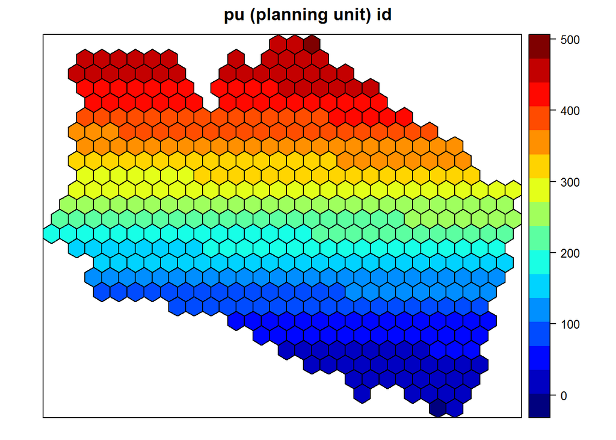

And our total species amounts per planning unit:

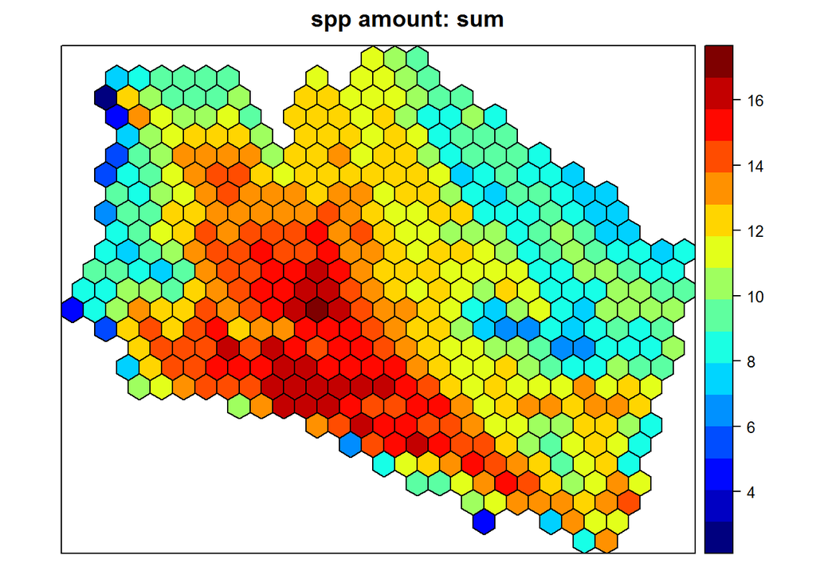

And table of species by sorted in descending order by sum of total amount:

| species_id | name | amount_sum |
| --- | --- | --- |
| 8 | Buteo regalis | 450.364244 |
| 20 | Solanum xanti | 427.140184 |
| 19 | Sciurus griseus | 425.132080 |
| 2 | Accipiter striatus | 417.391813 |
| 7 | Athene cunicularia | 398.177026 |
| 16 | Phrynosoma coronatum | 391.438638 |
| 11 | Elanus leucurus | 356.974060 |
| 15 | Passerina caerulea | 328.305514 |
| 6 | Antrozous pallidus | 317.469492 |
| 1 | Accipiter cooperii | 291.556007 |
| 4 | Ammodramus savannarum | 274.459942 |
| 14 | Mimulus aurantiacus | 259.777903 |
| 13 | Lanius ludovicianus | 207.936466 |
| 18 | Quercus parvula | 206.406835 |
| 10 | Cnemidophorus tigris | 199.491980 |
| 17 | Pinus muricata | 189.640617 |
| 12 | Icteria virens | 178.191228 |
| 5 | Amphispiza belli | 92.413993 |
| 9 | Catharus ustulatus | 30.520134 |
| 3 | Agelaius tricolor | 8.798618 |

Notice that some species still have relatively low abundance. Let’s plot a few different species amounts to see the spatial differences…

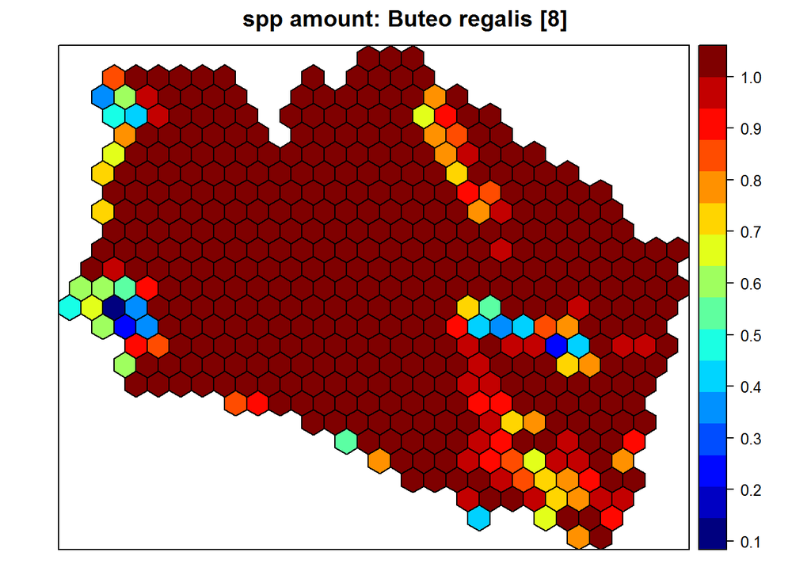

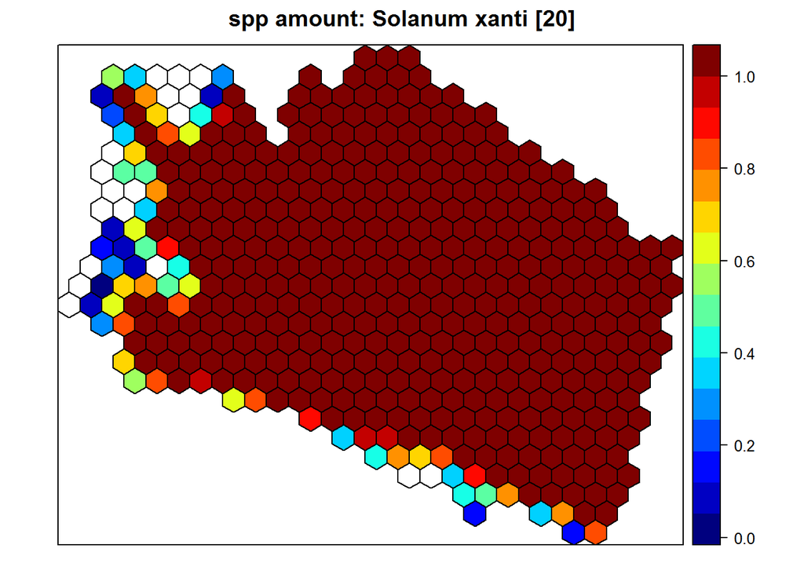

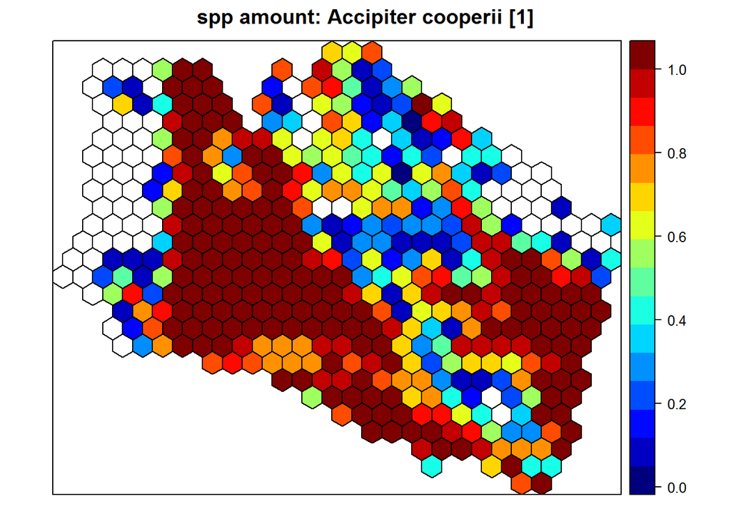

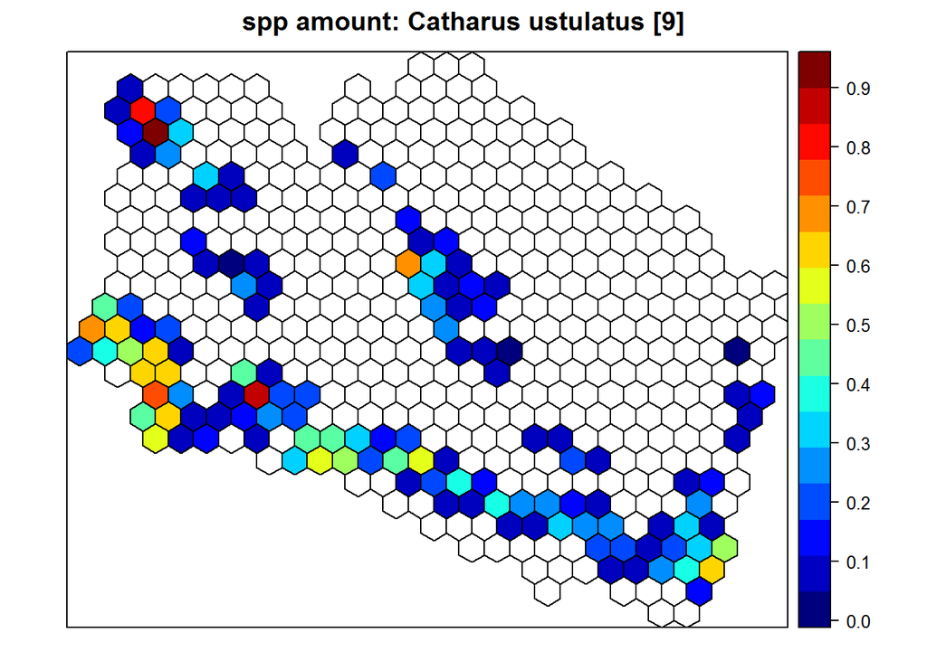

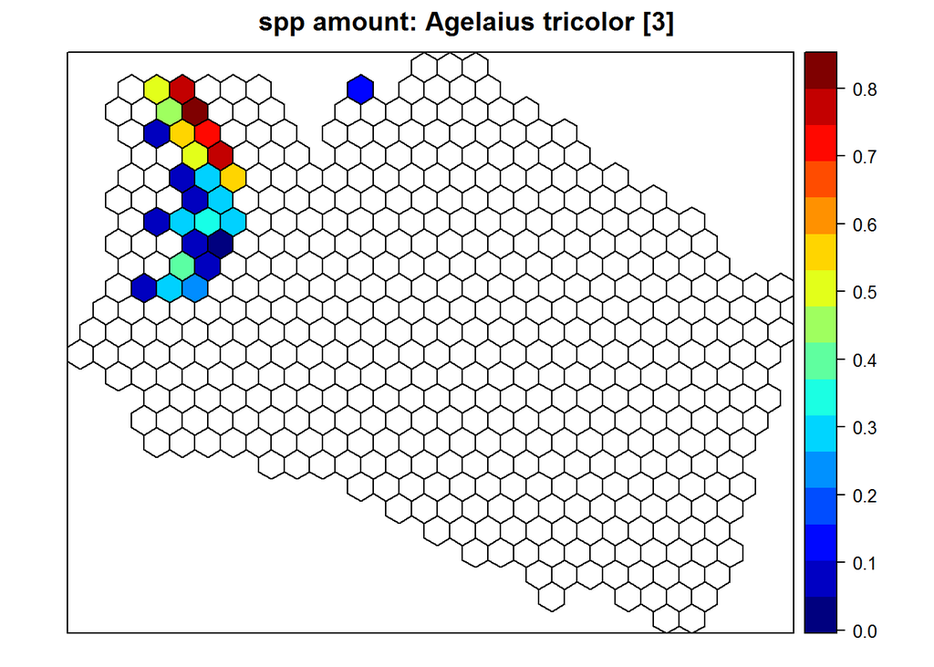

# 1 Run Marxan [scenario_01]

For your first Marxan scenario `scenario_01`, the input files have been created for you. Notice that the input paramaters (including paths to input files) are described in the `input.dat` text file can be edited in a GUI by double-clicking on `Inedit.exe`.

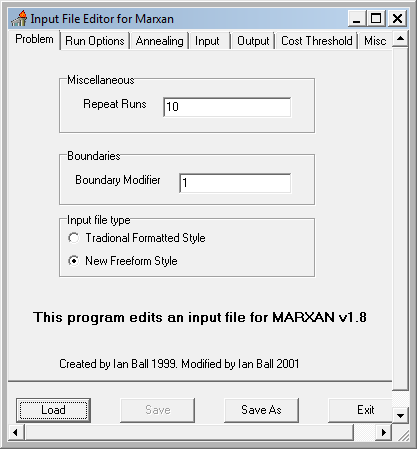

For quick tips on any of these parameters hover your cursor over the parameter. For thorough details, check out the manual and handbook in the `references` folder.

For this scenario, you shouldn’t change any of the paramaters or input files. You just need to double-click the `marxan.exe` executable inside the `scenario_01` folder to run Marxan. You should see a black command window open and show log output of Marxan for each run.

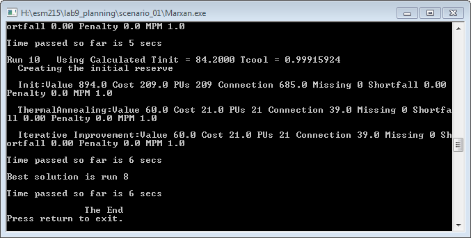

Once it’s finished, you can press return to exit.

Look at the output files generated by running Marxan, with dimensions [rows X columns] given for csv files:

- `DebugTraceFile_MarOpt.txt`: log output for debugging any errors
- `MarOptTotalAreas.csv`: initial total values for occurrence and amount of species across planning units
- `output/`
  - `out_best.txt` (csv): best run solution (0=excluded; 1=included) [planning units X solution]
  - `out_log.dat`: log output also to command window
  - `out_mvbest.txt` (csv): summary of conservation feature amounts met by the best solution [species X properties]
  - `out_sen.dat`: scenario details
  - `out_ssoln.txt` (csv): sum of all run solutions, planning units by number (0 to # of runs) [planning units X number]
  - `out_sum.txt` (csv): summary of each run [runs X properties]

Knit this document again to consume the Marxan outputs and plot a figure of the best solution (best) and sum of all solutions (ssoln), which for any planning unit has the maximum value of the number of runs. If a planning unit is at the max possible value of runs, then it may be considered “irreplacable” whereas the other planning units with lower values can be more flexibly swapped out to acheive a similar result.

```
## [1] "Marxan output file not found: scenario_01/output/out_best.txt"
```

**Question**: How many of the conservation features have their target amount met by the best solution?

# 2 Explore tradeoff between planning unit cost and conservation feature penalty [scenario_02]

Make a copy of scenario_01 and rename to `scenario_02`. I recommend deleting the files inside the `output` subfolder when you do this so you don’t get confused as to whether you ran Marxan yet or not for this scenario.

For this scenario, let’s explore the tradeoff between cost of planning units and penalty of not meeting conservation features. Based on the objective function (above equation), you would expect that if the cost of planning units was sufficiently high relative to the penalty of conservation features, you would get a best solution that would not meet all conservation feature targets, effectively switching the problem from a *minimum set* to *maximum coverage* problem.

Try this in by either increasing the cost of all planning units (pu.csv:cost = 1) or reducing the penalty of all conservation features (spp.csv:spf = 10) until you get an unmet conservation feature in the best solution, which you can quickly tell by any of the following methods:

1. in command window, scroll up to run of best solution, value to right of `Missing` > 0? (quickest)
2. in output_mvbest.txt:“Target Met” column has a No?
3. in output_sum.txt:“Missing_Values” column for run of best solution > 0?

Until you get an unmet conservation feature target, sequence by orders of magnitude (ie cost 1 to 10 to 100…, or spf 10 to 1 to 0.1…). (I recommend doing this by double-clicking the file to open in Excel, updating the first value and using the [lower-right of cell crosshair double-click trick](https://www.ablebits.com/office-addins-blog/2014/05/30/howto-use-autofill-excel/#double-click) to automatically fill down. Save the file to update CSV and disregard Excel’s suggestion to save in native format when closing.)

Knit again to plot the result below.

```
## [1] "Marxan output file not found: scenario_02/output/out_best.txt"
```

**Question**: At what combination of values for planning unit cost vs. conservation feature penalty did you get an unmet conservation feature in the selected set?

**Question**: Were more or fewer sites selected in the best solution than in scenario_01? Was there more or less flexibility in selection of sites between scenarios as evidenced in sum of solutions? Does this make sense to you based on the objective function?

# 3 Explore use of boundary length modifier (BLM) [scenario_03, scenario_04, scenario_05]

Make a copies of scenario_01 and rename to `scenario_03`, `scenario_04`, `scenario_05`. I recommend deleting the files inside the `output` subfolder when you do this so you don’t get confused as to whether you ran Marxan yet or not for this scenario.

For these scenarios, you’ll investigate the use of the boundary length modifier to clump selected planning units. Use the `Inedit.exe` to enter alternative values of BLM. Try 0.1, 1 and 10 for scenarios 3, 4 and 5 respectively.

```
## [1] "Marxan output file not found: scenario_03/output/out_best.txt"
```

```
## [1] "Marxan output file not found: scenario_04/output/out_best.txt"
```

```
## [1] "Marxan output file not found: scenario_05/output/out_best.txt"
```

**Question**: How many components (contiguous clusters of sites) are in each of your best solutions as a function of BLM?